# Homework 1

Lisa Eisler

9/19/2019

# Problem 1

In which we demonstrate the creation and manipulation of variable types and introduce coercion.

Here is a **code chunk** that creates hw1_df1 sampling from a *normal distribution*:

```r
hw1_df1 = tibble(
  normal = rnorm(8),
  normal_pos = normal > 0,
  name_char = c("My", "name", "is", "Lisa", "Danielle", "Eisler", "MD", "MS"),
  letter_factor = factor(c("Yes", "No", "Maybe", "Maybe", "No", "Yes", "Yes", "No"))
)
```

The mean of the numeric variable is 0.1314544. The mean of the logical variable is 0.625. The mean of the character variable is NA. The mean of the factor variable is NA. I am unable to take the mean of character and factor variables.

Here is a **code chunk** that creates hw1_numeric_df1 sampling from a *normal distribution*, converting our original logical, character, and factor variables to numeric.

```r
 hw1numeric_df1 = tibble(
  normal = rnorm(8),
  normal_pos = as.numeric(normal > 0),
  name_char = as.numeric(c("My", "name", "is", "Lisa", "Danielle", "Eisler", "MD", "MS")),
  letter_factor = as.numeric(factor(c("Yes", "No", "Maybe", "Maybe", "No", "Yes", "Yes", "No")))
)
```

Logical variable values are convereted to numbers: True is converted to 1 and False is converted to 0. Factor variable values are converted to a number corresponding to level: A:1, B:2, C:3, etc. Character variable values are converted to NA.

This may explain why we are able to calculate the mean of a logical variable, even prior to converting it to numeric.

Lastly, here is a **code chunk** which creates hw1convert_df1, sampling from a *normal distribution* and demonstrates conversion and nested conversion of logical variables, with column cross products.

```r
hw1convert_df1 = tibble(
  normal = rnorm(8),
  normal_pos_numeric = as.numeric(normal > 0),
  normal_pos_factor = as.factor(normal > 0),
  normal_pos_numeric_factor = as.numeric(as.factor(normal > 0)),
  product_1 = normal*normal_pos_numeric,
  product_2 = normal*normal_pos_factor,
  product_3 = normal*normal_pos_numeric_factor
)
```

# Problem 2

In which we demonstrate the use of inline r code and create color-coded scatter plots

Here is a **code chunk** that creates hw1_df2 sampling from a *normal distribution*:

```r
hw1_df2 = tibble(
  x = rnorm(500),
  y = rnorm(500),
  sum_greater1 = x + y > 1,
  sum_greater1numeric = as.numeric(x + y > 1),
  sum_greater1factor = as.factor(sum_greater1numeric)
)
```

The number of rows is 500. The number of columns is 5. The mean of x is 0.0098297. The median of x is -0.0419746. The standard deviation of x is 1.0154157. The proportion of cases for which x + y > 1 is True is 0.25.

Here is a scatter plot adding color using logical variable.

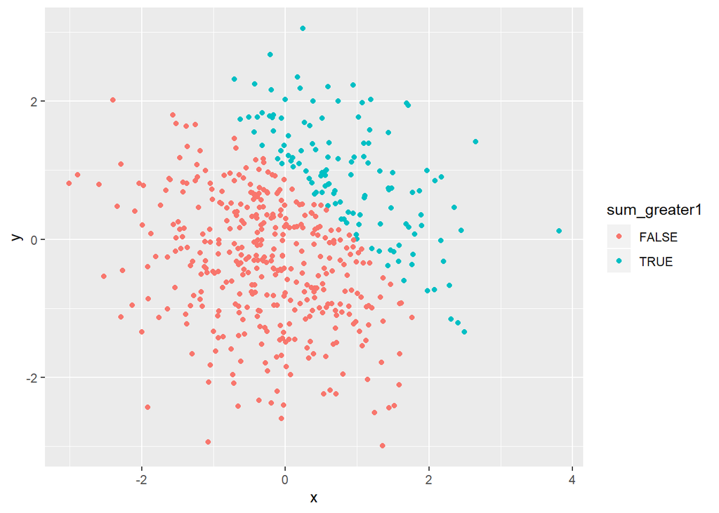

```r
ggplot(hw1_df2, aes(x = x, y = y, color = sum_greater1)) + geom_point()
```

Here is a scatter plot adding color using numeric variable.

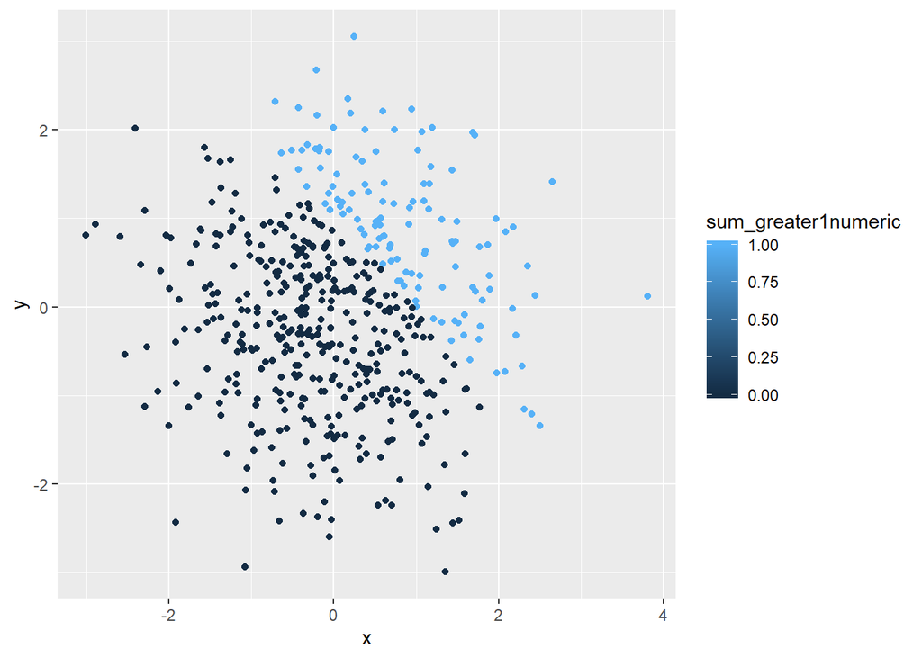

```r
ggplot(hw1_df2, aes(x = x, y = y, color = sum_greater1numeric)) + geom_point()
```

Here is a scatter plot adding color using factor variable.

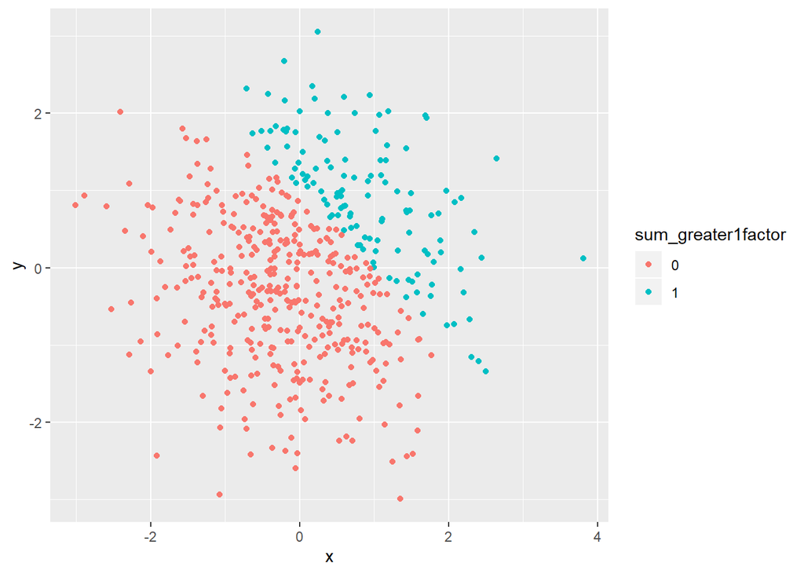

```r
ggplot(hw1_df2, aes(x = x, y = y, color = sum_greater1factor)) + geom_point()
```